# EDA — `01_master` (RISA_DATA_V1.0)

**HealthSignal LATAM · Hackathon Perú 2026**

Este notebook explora las 4 tablas maestras de la Red Integrada de Salud Andina (RISA): `patients`, `encounters`, `devices` y `healthcare_facilities`.

Estas tablas son el **backbone relacional** del resto del pipeline: todo lo que venga de `02_clinical` (labs, condiciones, medicamentos), `03_monitoring` (signos vitales, wearables, dispositivos IoT) y `04_context` se conecta a esta capa vía `patient_id` / `facility_id` / `device_id`. Por eso el objetivo de este EDA no es solo "ver los datos", sino:

1. Confirmar la **integridad referencial** (¿todo encaja entre tablas?).
2. Entender la **composición de la cohorte** (edad, sexo, región, programa de atención, riesgo basal).
3. Mapear la **heterogeneidad de la red** (7 centros con distinta madurez digital y conectividad) — clave porque esa heterogeneidad es la que después genera desalineación temporal y ruido en `03_monitoring`.
4. Dejar documentadas señales de calidad de datos (nulos, duplicados, outliers) a este nivel, como línea base antes de integrar las fuentes más pesadas.

```python
import pandas as pd
import numpy as np
import matplotlib.pyplot as plt
import seaborn as sns

pd.set_option('display.max_columns', 50)
pd.set_option('display.width', 160)
sns.set_theme(style='whitegrid', palette='Set2')
plt.rcParams['figure.dpi'] = 110

DATA_DIR = "../data/raw/01_master"  # ejecutar desde notebooks/ dentro del repo

patients     = pd.read_csv(f"{DATA_DIR}/patients.csv")
encounters   = pd.read_csv(f"{DATA_DIR}/encounters.csv", parse_dates=["start_datetime", "end_datetime"])
devices      = pd.read_csv(f"{DATA_DIR}/devices.csv")
facilities   = pd.read_csv(f"{DATA_DIR}/healthcare_facilities.csv")

for name, df in [("patients", patients), ("encounters", encounters),
                  ("devices", devices), ("healthcare_facilities", facilities)]:
    print(f"{name:22s} -> {df.shape[0]:5d} filas x {df.shape[1]} columnas")
```

```
patients               ->  1000 filas x 9 columnas
encounters             ->  1000 filas x 10 columnas
devices                ->  2000 filas x 11 columnas
healthcare_facilities  ->     7 filas x 8 columnas
```

## 1. `patients` — cohorte de pacientes

1000 pacientes sintéticos. Veamos estructura, tipos y una muestra.

```python
print(patients.dtypes)
patients.head()
```

```
patient_id                 str
sex_at_birth               str
age_years                int64
age_group                  str
region_type                str
care_program               str
baseline_risk_profile      str
enrollment_date            str
active                    bool
dtype: object
```

|  | patient_id | sex_at_birth | age_years | age_group | region_type | care_program | baseline_risk_profile | enrollment_date | active |
| --- | --- | --- | --- | --- | --- | --- | --- | --- | --- |
| 0 | PAT-0001 | M | 64 | 60-74 | URBAN | AMBULATORY | GENERAL | 2026-04-03 | True |
| 1 | PAT-0002 | F | 18 | 18-39 | URBAN | AMBULATORY | GENERAL | 2026-05-08 | True |
| 2 | PAT-0003 | F | 65 | 60-74 | PERIURBAN | AMBULATORY | GENERAL | 2026-05-16 | True |
| 3 | PAT-0004 | F | 79 | 75+ | PERIURBAN | HOME_MONITORING | METABOLIC_CONTEXT | 2026-01-05 | True |
| 4 | PAT-0005 | M | 78 | 75+ | URBAN | AMBULATORY | METABOLIC_CONTEXT | 2026-02-03 | True |

### 1.1 Calidad de datos: nulos y duplicados

A este nivel maestro **no hay nulos ni filas duplicadas** — es esperable, ya que las imperfecciones del dataset (según el contexto oficial de RISA) se concentran en las tablas clínicas y de monitoreo, no en la capa maestra de identidad del paciente.

```python
print("Nulos por columna:")
print(patients.isnull().sum())
print("\nFilas duplicadas exactas:", patients.duplicated().sum())
print("patient_id únicos:", patients['patient_id'].nunique(), "/", len(patients))
```

```
Nulos por columna:
patient_id               0
sex_at_birth             0
age_years                0
age_group                0
region_type              0
care_program             0
baseline_risk_profile    0
enrollment_date          0
active                   0
dtype: int64

Filas duplicadas exactas: 0
patient_id únicos: 1000 / 1000
```

### 1.2 Distribución demográfica y clínica de la cohorte

- Edad: media ~55 años, rango 18–90 → cohorte adulta-mayor con presencia relevante de jóvenes-adultos (importante para calibrar umbrales de signos vitales por grupo etario).
- Sexo balanceado (51% F / 49% M).
- 542 urbanos, 260 periurbanos, 198 rurales → la mezcla de región es clave porque se cruza con la madurez digital de cada centro (ver sección 4): pacientes rurales probablemente reciben datos con más huecos/latencia.
- 4 programas de atención y 4 perfiles de riesgo basal, sin dominancia extrema de ninguno.

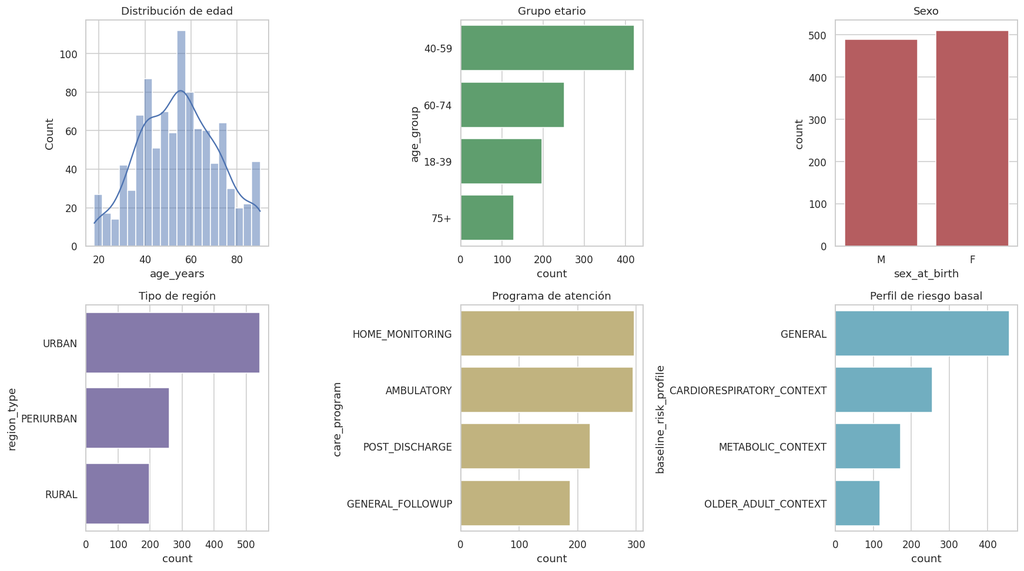

```python
fig, axes = plt.subplots(2, 3, figsize=(16, 9))

sns.histplot(patients['age_years'], bins=20, kde=True, ax=axes[0,0], color='#4C72B0')
axes[0,0].set_title('Distribución de edad')

sns.countplot(data=patients, y='age_group', order=patients['age_group'].value_counts().index,
              ax=axes[0,1], color='#55A868')
axes[0,1].set_title('Grupo etario')

sns.countplot(data=patients, x='sex_at_birth', ax=axes[0,2], color='#C44E52')
axes[0,2].set_title('Sexo')

sns.countplot(data=patients, y='region_type', order=patients['region_type'].value_counts().index,
              ax=axes[1,0], color='#8172B2')
axes[1,0].set_title('Tipo de región')

sns.countplot(data=patients, y='care_program', order=patients['care_program'].value_counts().index,
              ax=axes[1,1], color='#CCB974')
axes[1,1].set_title('Programa de atención')

sns.countplot(data=patients, y='baseline_risk_profile',
              order=patients['baseline_risk_profile'].value_counts().index,
              ax=axes[1,2], color='#64B5CD')
axes[1,2].set_title('Perfil de riesgo basal')

plt.tight_layout()
plt.show()
```

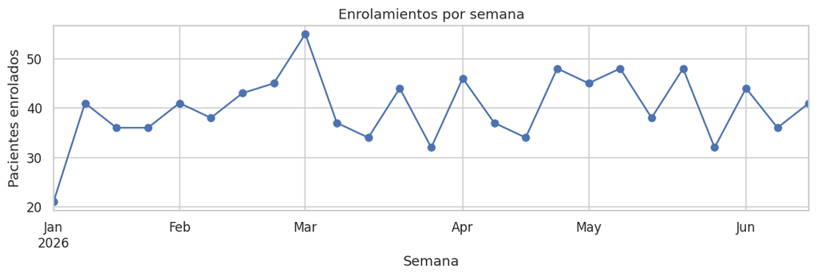

```
Rango de enrolamiento: 2026-01-02 → 2026-06-21
```

```python
patients['enrollment_date'] = pd.to_datetime(patients['enrollment_date'])
plt.figure(figsize=(10, 3.5))
patients.set_index('enrollment_date').resample('W').size().plot(marker='o', color='#4C72B0')
plt.title('Enrolamientos por semana')
plt.ylabel('Pacientes enrolados')
plt.xlabel('Semana')
plt.tight_layout()
plt.show()
print("Rango de enrolamiento:", patients['enrollment_date'].min().date(), "→", patients['enrollment_date'].max().date())
```

## 2. `encounters` — episodios de atención/monitoreo

1000 encuentros, **exactamente 1 por paciente** (relación 1:1 a este nivel del dataset: cada paciente tiene un único episodio "ancla" que probablemente enmarca la ventana de monitoreo que se explota en `03_monitoring`).

```python
print(encounters.dtypes)
encounters.head()
```

```
encounter_id                  str
patient_id                    str
facility_id                   str
encounter_type                str
start_datetime     datetime64[us]
end_datetime       datetime64[us]
care_setting                  str
reason_category               str
source_system                 str
status                        str
dtype: object
```

|  | encounter_id | patient_id | facility_id | encounter_type | start_datetime | end_datetime | care_setting | reason_category | source_system | status |
| --- | --- | --- | --- | --- | --- | --- | --- | --- | --- | --- |
| 0 | ENC-000001 | PAT-0001 | FAC-05 | HOME_MONITORING_EPISODE | 2026-07-10 09:00:00 | 2026-07-19 09:00:00 | HOME | SYNTHETIC_MONITORING | EHR_CORE | COMPLETED |
| 1 | ENC-000002 | PAT-0002 | FAC-01 | HOSPITAL_OBSERVATION | 2026-07-11 10:00:00 | 2026-07-20 10:00:00 | FACILITY | SYNTHETIC_MONITORING | EHR_CORE | COMPLETED |
| 2 | ENC-000003 | PAT-0003 | FAC-01 | HOSPITAL_OBSERVATION | 2026-07-12 11:00:00 | 2026-07-21 11:00:00 | FACILITY | SYNTHETIC_MONITORING | EHR_CORE | COMPLETED |
| 3 | ENC-000004 | PAT-0004 | FAC-05 | HOME_MONITORING_EPISODE | 2026-07-13 12:00:00 | 2026-07-22 12:00:00 | HOME | SYNTHETIC_MONITORING | EHR_CORE | COMPLETED |
| 4 | ENC-000005 | PAT-0005 | FAC-01 | HOSPITAL_OBSERVATION | 2026-07-14 08:00:00 | 2026-07-23 08:00:00 | FACILITY | SYNTHETIC_MONITORING | EHR_CORE | COMPLETED |

```python
print("Nulos por columna:")
print(encounters.isnull().sum())
print("\nDuplicados:", encounters.duplicated().sum())
print("Encuentros por paciente (describe):")
print(encounters['patient_id'].value_counts().describe())
```

```
Nulos por columna:
encounter_id       0
patient_id         0
facility_id        0
encounter_type     0
start_datetime     0
end_datetime       0
care_setting       0
reason_category    0
source_system      0
status             0
dtype: int64

Duplicados: 0
Encuentros por paciente (describe):
count    1000.0
mean        1.0
std         0.0
min         1.0
25%         1.0
50%         1.0
75%         1.0
max         1.0
Name: count, dtype: float64
```

`reason_category`, `source_system` y `status` son **constantes** (una sola categoría cada una) en esta versión del dataset — no aportan varianza por sí solas, pero sí sirven como filtro/ancla al cruzar con otras tablas.

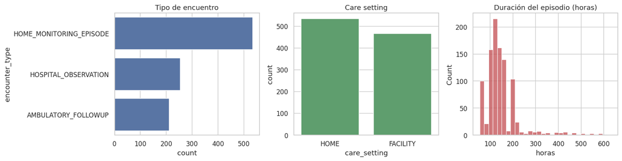

```
Duración (horas) — describe:
count    1000.00000
mean      148.77850
std        76.81875
min        53.75000
25%        96.00000
50%       144.00000
75%       168.00000
max       633.00000
dtype: float64
```

```python
fig, axes = plt.subplots(1, 3, figsize=(15, 4))

sns.countplot(data=encounters, y='encounter_type',
              order=encounters['encounter_type'].value_counts().index, ax=axes[0], color='#4C72B0')
axes[0].set_title('Tipo de encuentro')

sns.countplot(data=encounters, x='care_setting', ax=axes[1], color='#55A868')
axes[1].set_title('Care setting')

duration_h = (encounters['end_datetime'] - encounters['start_datetime']).dt.total_seconds() / 3600
sns.histplot(duration_h, bins=30, ax=axes[2], color='#C44E52')
axes[2].set_title('Duración del episodio (horas)')
axes[2].set_xlabel('horas')

plt.tight_layout()
plt.show()

print("Duración (horas) — describe:")
print(duration_h.describe())
```

**Comentario:** la duración de los episodios va de ~54 h a ~633 h (más de 26 días), con una mediana de 144 h (6 días). Los episodios `HOME_MONITORING_EPISODE` (534) dominan sobre `HOSPITAL_OBSERVATION` (255) y `AMBULATORY_FOLLOWUP` (211). Esto importa porque **la ventana de observación no es uniforme entre pacientes** — cualquier feature temporal/agregado en el pipeline de riesgo debe normalizarse por duración de ventana, no asumir un horizonte fijo.

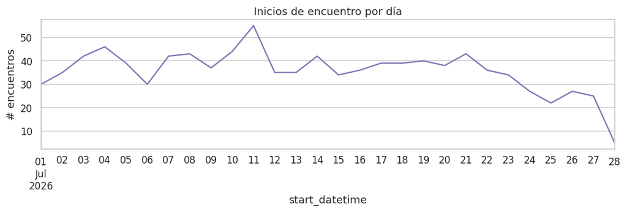

```
Rango de fechas de inicio: 2026-07-01 00:00:00 → 2026-07-28 18:15:00
```

```python
plt.figure(figsize=(10, 3.5))
encounters.set_index('start_datetime').resample('D').size().plot(color='#8172B2')
plt.title('Inicios de encuentro por día')
plt.ylabel('# encuentros')
plt.tight_layout()
plt.show()
print("Rango de fechas de inicio:", encounters['start_datetime'].min(), "→", encounters['start_datetime'].max())
```

## 3. `devices` — dispositivos e IoT asignados

2000 registros de dispositivo. Cada paciente tiene **exactamente 2 dispositivos activos y dedicados**: 1 wearable de muñeca (`WRIST_WEARABLE`) siempre presente, más 1 monitor (`HOME_MONITOR` o `CLINICAL_MONITOR`, mutuamente excluyentes por paciente).

```python
print(devices.dtypes)
devices.head()
```

```
device_id                   str
device_type                 str
manufacturer_class          str
model_family                str
measurement_domain          str
sampling_profile            str
reliability_class           str
facility_id                 str
patient_assignment_type     str
active                     bool
assigned_patient_id         str
dtype: object
```

|  | device_id | device_type | manufacturer_class | model_family | measurement_domain | sampling_profile | reliability_class | facility_id | patient_assignment_type | active | assigned_patient_id |
| --- | --- | --- | --- | --- | --- | --- | --- | --- | --- | --- | --- |
| 0 | DEV-00001 | HOME_MONITOR | RISA_SYNTHETIC | M-2 | MULTIVARIATE | VARIABLE | R2_STANDARD | FAC-05 | DEDICATED | True | PAT-0001 |
| 1 | WRB-00001 | WRIST_WEARABLE | RISA_SYNTHETIC | W-2 | ACTIVITY_AND_PULSE | 5-15 min | R2_STANDARD | FAC-07 | DEDICATED | True | PAT-0001 |
| 2 | DEV-00002 | HOME_MONITOR | RISA_SYNTHETIC | M-3 | MULTIVARIATE | VARIABLE | R2_STANDARD | FAC-05 | DEDICATED | True | PAT-0002 |
| 3 | WRB-00002 | WRIST_WEARABLE | RISA_SYNTHETIC | W-3 | ACTIVITY_AND_PULSE | 5-15 min | R3_VARIABLE | FAC-07 | DEDICATED | True | PAT-0002 |
| 4 | DEV-00003 | HOME_MONITOR | RISA_SYNTHETIC | M-4 | MULTIVARIATE | VARIABLE | R3_VARIABLE | FAC-05 | DEDICATED | True | PAT-0003 |

```python
print("Nulos por columna:")
print(devices.isnull().sum())
print("Duplicados:", devices.duplicated().sum())
print("\nDispositivos por paciente (describe):")
print(devices.groupby('assigned_patient_id').size().describe())
print("\n¿Algún paciente con 2 monitores o 0 wearables?")
per_patient_type = devices.pivot_table(index='assigned_patient_id', columns='device_type',
                                        values='device_id', aggfunc='count', fill_value=0)
print((per_patient_type['WRIST_WEARABLE'] != 1).sum(), "pacientes sin exactamente 1 wearable")
print(((per_patient_type.get('HOME_MONITOR',0) + per_patient_type.get('CLINICAL_MONITOR',0)) != 1).sum(),
      "pacientes sin exactamente 1 monitor (home o clínico)")
```

```
Nulos por columna:
device_id                  0
device_type                0
manufacturer_class         0
model_family               0
measurement_domain         0
sampling_profile           0
reliability_class          0
facility_id                0
patient_assignment_type    0
active                     0
assigned_patient_id        0
dtype: int64
Duplicados: 0

Dispositivos por paciente (describe):
count    1000.0
mean        2.0
std         0.0
min         2.0
25%         2.0
50%         2.0
75%         2.0
max         2.0
dtype: float64

¿Algún paciente con 2 monitores o 0 wearables?
0 pacientes sin exactamente 1 wearable
0 pacientes sin exactamente 1 monitor (home o clínico)
```

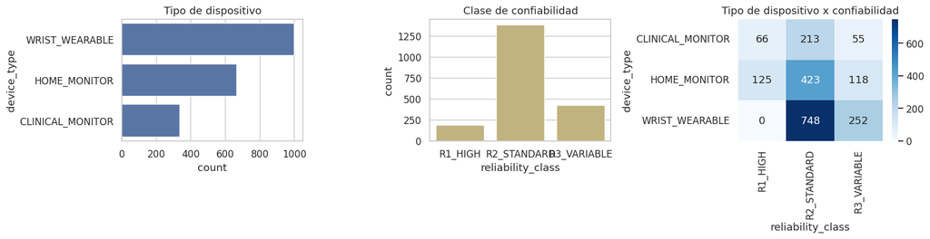

```python
fig, axes = plt.subplots(1, 3, figsize=(15, 4))

sns.countplot(data=devices, y='device_type',
              order=devices['device_type'].value_counts().index, ax=axes[0], color='#4C72B0')
axes[0].set_title('Tipo de dispositivo')

sns.countplot(data=devices, x='reliability_class',
              order=['R1_HIGH','R2_STANDARD','R3_VARIABLE'], ax=axes[1], color='#CCB974')
axes[1].set_title('Clase de confiabilidad')

ct = pd.crosstab(devices['device_type'], devices['reliability_class'])
sns.heatmap(ct, annot=True, fmt='d', cmap='Blues', ax=axes[2])
axes[2].set_title('Tipo de dispositivo x confiabilidad')

plt.tight_layout()
plt.show()
```

**Comentario clave:** la clase de confiabilidad (`R1_HIGH` / `R2_STANDARD` / `R3_VARIABLE`) está distribuida de forma desigual entre tipos de dispositivo (ver heatmap). Esto es una señal de diseño del dataset: los dispositivos `R3_VARIABLE` son candidatos directos a producir el ruido, muestreo irregular y gaps que se mencionan en el reto — conviene propagar `reliability_class` como feature/flag de confianza en el pipeline de señales, no descartarla en el EDA.

## 4. `healthcare_facilities` — red de 7 centros

Tabla pequeña (7 filas) pero **crítica para explicar heterogeneidad**: cada centro tiene su propio nivel de madurez digital y perfil de conectividad, lo que en la práctica determina qué tan completos/oportunos llegan los datos de monitoreo de cada paciente según dónde es atendido.

```python
facilities
```

|  | facility_id | facility_name | facility_type | region_type | digital_maturity | connectivity_profile | monitoring_capability | laboratory_capability |
| --- | --- | --- | --- | --- | --- | --- | --- | --- |
| 0 | FAC-01 | Hospital Central Andino | HOSPITAL | URBAN | HIGH | STABLE | CONTINUOUS | FULL |
| 1 | FAC-02 | Clinica Metropolitana | CLINIC | URBAN | MEDIUM_HIGH | STABLE | PERIODIC | STANDARD |
| 2 | FAC-03 | Centro Primario Norte | PRIMARY_CARE | PERIURBAN | MEDIUM | INTERMITTENT | SPOT | BASIC |
| 3 | FAC-04 | Centro Primario Valle | PRIMARY_CARE | RURAL | MEDIUM_LOW | INTERMITTENT | SPOT | BASIC |
| 4 | FAC-05 | Programa RISA en Casa | HOME_MONITORING | MIXED | VARIABLE | VARIABLE | REMOTE | NONE |
| 5 | FAC-06 | Red de Laboratorios RISA | LABORATORY | URBAN | HIGH | STABLE | NONE | FULL |
| 6 | FAC-07 | Centro de Telemonitoreo | TELEMONITORING_CENTER | URBAN | HIGH | STABLE | REMOTE | NONE |

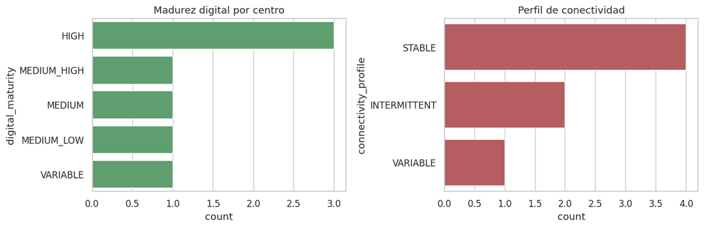

```python
fig, axes = plt.subplots(1, 2, figsize=(12, 4))

order_dm = ['HIGH','MEDIUM_HIGH','MEDIUM','MEDIUM_LOW','VARIABLE']
sns.countplot(data=facilities, y='digital_maturity',
              order=[o for o in order_dm if o in facilities['digital_maturity'].unique()],
              ax=axes[0], color='#55A868')
axes[0].set_title('Madurez digital por centro')

sns.countplot(data=facilities, y='connectivity_profile', ax=axes[1], color='#C44E52')
axes[1].set_title('Perfil de conectividad')

plt.tight_layout()
plt.show()
```

**Comentario:** 3 de 7 centros tienen conectividad `INTERMITTENT`/`VARIABLE` (los centros de atención primaria y el programa domiciliario) — justo los perfiles de menor madurez digital. Esto confirma, a nivel de metadatos, la hipótesis central del reto: **la calidad de la señal va a depender de por dónde entró el dato**, y esa procedencia (`facility_id` → `digital_maturity` / `connectivity_profile`) debería viajar como contexto en cada alerta para hacerla explicable ("esta lectura viene de un centro con conectividad intermitente").

## 5. Relaciones cruzadas entre tablas

Cruces vía `patient_id` / `facility_id` para ver cómo se reparte la cohorte sobre la red y si hay combinaciones perfil de riesgo × programa de atención que concentren pacientes.

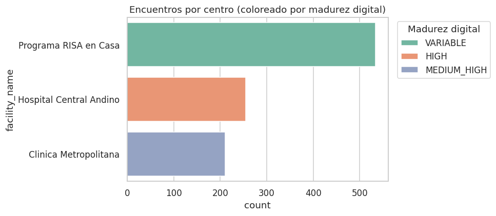

```python
enc_fac = encounters.merge(facilities[['facility_id','facility_name','digital_maturity']], on='facility_id', how='left')

plt.figure(figsize=(9, 4))
order_fac = enc_fac['facility_name'].value_counts().index
sns.countplot(data=enc_fac, y='facility_name', order=order_fac, hue='digital_maturity', dodge=False)
plt.title('Encuentros por centro (coloreado por madurez digital)')
plt.legend(title='Madurez digital', bbox_to_anchor=(1.02, 1), loc='upper left')
plt.tight_layout()
plt.show()
```

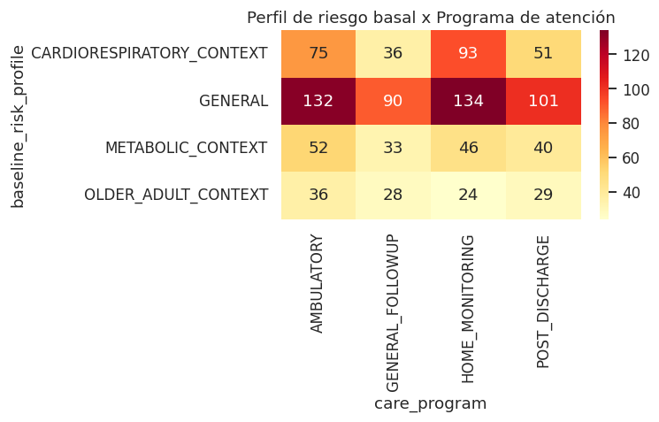

```python
ct = pd.crosstab(patients['baseline_risk_profile'], patients['care_program'])
plt.figure(figsize=(7, 4.5))
sns.heatmap(ct, annot=True, fmt='d', cmap='YlOrRd')
plt.title('Perfil de riesgo basal x Programa de atención')
plt.tight_layout()
plt.show()
```

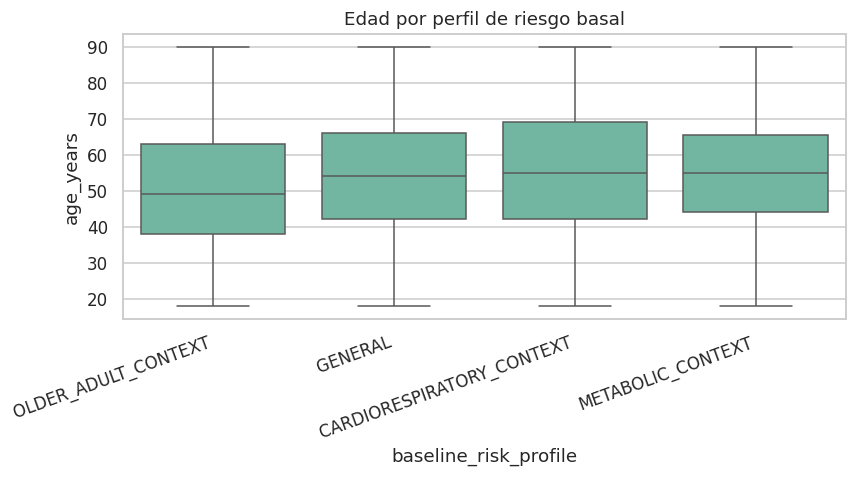

```python
plt.figure(figsize=(8, 4.5))
sns.boxplot(data=patients, x='baseline_risk_profile', y='age_years',
            order=patients.groupby('baseline_risk_profile')['age_years'].median().sort_values().index)
plt.xticks(rotation=20, ha='right')
plt.title('Edad por perfil de riesgo basal')
plt.tight_layout()
plt.show()
```

**Siguiente paso sugerido:** repetir un EDA dirigido en `02_clinical` (donde sí se esperan nulos/ outliers) y usar `patient_id` + `facility_id` de esta capa para alinear temporalmente los datos de `03_monitoring` por paciente.